```python
from IPython.display import HTML
```

```python
HTML('''<script>
code_show=true;
function code_toggle() {
 if (code_show){
 $('div.input').hide();
 } else {
 $('div.input').show();
 }
 code_show = !code_show
}
$( document ).ready(code_toggle);
</script>
The raw code for this IPython notebook is by default hidden for easier reading.
To toggle on/off the raw code, click <a href="javascript:code_toggle()">here</a>.''')
```

The raw code for this IPython notebook is by default hidden for easier reading. To toggle on/off the raw code, click here.

# Learning the M0/M1 task with PyCaffe (caffe-segnet flavor)

The purpose of this notebook is to explore transfer learning and end-to-end learning on the M0 / M1 tile classification task.

Some weights and caffe .prototxt net definition* provided:  
https://github.com/BVLC/caffe/tree/master/models/bvlc_alexnet

*Modified slightly to not use the `Input` data layer, because my caffe-segnet installation is based on an old commit of `caffe-master`, which does not include that data layer. Update: I've upgraded the SegNet repo to one based on a newer Caffe Master branch. There is work todo for testing older model compatability with this new installation.

TODO: http://nbviewer.jupyter.org/github/BVLC/caffe/blob/master/examples/net_surgery.ipynb

Inspiration: http://nbviewer.jupyter.org/github/BVLC/caffe/blob/master/examples/00-classification.ipynb

```python
%run /Users/nathaning/local_projects/mzmo/code/classificationFns.py #Import functions from external file
```

## Define several networks trained in different ways, with the same M0 and M1 tiles

| Architecture | Weights Initialized | End classifier | Training Task | Note |
| --- | --- | --- | --- | --- |
| AlexNet | ImageNet pre-training | SoftMax linear classifier | ImageNet (1000 classes) | [BVLC Weights](https://dl.caffe.berkeleyvision.org) |
| AlexNet | Random initialization | SoftMax linear classifier | M0/M1 (2 classes) | Multiplied data |
| AlexNet | ImageNet pre-training | SoftMax linear classifier | M0/M1 (2 classes) | Multiplied data |
| GoogLeNet | Random initialization | SoftMax linear classifier | M0/M1 (2 classes) | Non-multiplied data |

```python
# 1 AlexNet trained on ImageNet dataset (1000 real-world classes)
imagenet_weights = '/Users/nathaning/local_projects/mzmo/weights/bvlc_alexnet.caffemodel'
imagenet_netdef = '/Users/nathaning/local_projects/mzmo/code/modeldefs/alexnet_deploy.prototxt'
net_bvlc = define_network(imagenet_netdef, imagenet_weights)

# 2 End to end trained on the M0 / M1 problem
end2end_weights = '/Users/nathaning/local_projects/mzmo/weights/local_alexnet_jan4_iter_20000.caffemodel'
end2end_netdef = '/Users/nathaning/local_projects/mzmo/code/modeldefs/alexnet_mzmo_deploy.prototxt'
net_end2end = define_network(end2end_netdef, end2end_weights)

# 3 ImageNet weights transferred, and the last layer trained on the M0 / M1 problem
transfer_weights = '/Users/nathaning/local_projects/mzmo/weights/transfer_alexnet_jan10_iter_40000.caffemodel'
transfer_netdef = '/Users/nathaning/local_projects/mzmo/code/modeldefs/alexnet_mzmo_deploy.prototxt'
net_transfer = define_network(transfer_netdef, transfer_weights)

# 4 GoogLeNet trained in the Digits Ecosystem (max. accuracy ~ 80%) ## 224x224 input size
#google_weights = '/Users/nathaning/local_projects/mzmo/weights/googlenet_epoch_100/snapshot_iter_1400.caffemodel'
#google_netdef = '/Users/nathaning/local_projects/mzmo/weights/googlenet_epoch_100/deploy.prototxt'
#net_google = define_network(google_netdef, google_weights)

# Lung pattern classification learned end to end
#lung_weights = '/Users/nathaning/local_projects/semantic-lung/weights/Lung_Alexnet_iter_100000.caffemodel'
#lung_netdef = '/Users/nathaning/local_projects/semantic-lung/code/deploy.prototxt'
#net_lung = define_network(lung_netdef, lung_weights)

# Prostate Cancer growth pattern SegNet
#seg_weights = '/Users/nathaning/Dropbox/projects/semantic_pca/weights/pca_segnet_dec7_norm_65000.caffemodel'
#seg_netdef = '/Users/nathaning/local_projects/mzmo/code/semantic/segnet_basic_inference_jupyter.prototxt'
#net_seg = define_network(seg_netdef, seg_weights)
```

```python
%matplotlib inline
```

## Histology image data:

I have two folders: one with all tiles from M0 and one with all tiles from M1:

- M0 has 1200 tiles
- M1 has 2046 tiles

Run all through AlexNet with transferred weights from the ImageNet classificaiton task

```python
m0_path = '/Users/nathaning/local_projects/mzmo/data/m0_256'
m1_path = '/Users/nathaning/local_projects/mzmo/data/m1_256'

m0_images = glob.glob(os.path.join(m0_path, '*.tif'))
m1_images = glob.glob(os.path.join(m1_path, '*.tif'))
```

Transfer learning network fine-tuned to the M0/M1 task

```python
m0_correct = 0
m1_correct = 0


for m0_img in m0_images:
    img = get_img(m0_img, 227) # Resize each 256 --> 227
    net_transfer, label = infer(net_transfer, img)
    m0_correct+=(label == 0)
    #print "Image {} classified as \t{}".format(m0_img, label)

for m1_img in m1_images:
    img = get_img(m1_img, 227) # Resize each 256 --> 227
    net_transfer, label = infer(net_transfer, img)
    m1_correct+=(label == 1)
    #print "Image {} classified as \t{}".format(m1_img, label)


print "Number of M0 images classified as M0: {}".format(m0_correct)
print "Number of M1 images classified as M1: {}".format(m1_correct)
```

```
Number of M0 images classified as M0: 1200
Number of M1 images classified as M1: 0
```

End to end training on the M0 / M1 task

```python
m0_correct = 0
m1_correct = 0


for m0_img in m0_images:
    img = get_img(m0_img, 227) # Resize each 256 --> 227
    net_end2end, label = infer(net_end2end, img)
    m0_correct+=(label == 0)
    #print "Image {} classified as \t{}".format(m0_img, label)

for m1_img in m1_images:
    img = get_img(m1_img, 227) # Resize each 256 --> 227
    net_end2end, label = infer(net_end2end, img)
    m1_correct+=(label == 1)
    #print "Image {} classified as \t{}".format(m1_img, label)


print "Number of M0 images classified as M0: {}".format(m0_correct)
print "Number of M1 images classified as M1: {}".format(m1_correct)
```

```
Number of M0 images classified as M0: 1155
Number of M1 images classified as M1: 113
```

GoogLeNet, trained end to end on the M0/M1 task

```python
m0_correct = 0
m1_correct = 0

for m0_img in m0_images:
    img = get_img(m0_img, 224) # Resize each 256 --> 224
    net_google, label = infer(net_google, img, 'softmax')
    m0_correct+=(label == 0)
    #print "Image {} classified as \t{}".format(m0_img, label)

for m1_img in m1_images:
    img = get_img(m1_img, 224) # Resize each 256 --> 224
    net_google, label = infer(net_google, img, 'softmax')
    m1_correct+=(label == 1)
    #print "Image {} classified as \t{}".format(m1_img, label)


print "Number of M0 images classified as M0: {}".format(m0_correct)
print "Number of M1 images classified as M1: {}".format(m1_correct)
```

```
Number of M0 images classified as M0: 0
Number of M1 images classified as M1: 2046
```

But, GoogLeNet requires mean image subtraction. Using the Digits pipeline ensures the data is preprocessed properly.

Using all images for testing, **including the 80% training set**:

- M0 accuracy = 794.0/1200 = 66%
- M1 accuracy = 1815/2046 = 88%

## Weights & Activations in response to a histology image

Input image: (show code and re-run the cell to refresh with a new image):

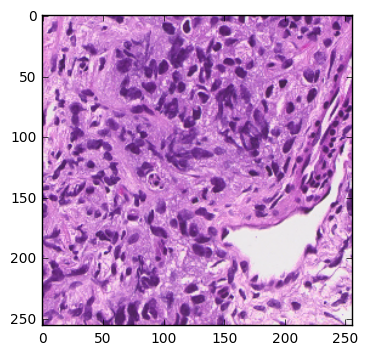

```python
img_path = '/Users/nathaning/local_projects/mzmo/data/m1_256' # M1 tiles
img_list = list_images(img_path)

img_index = int(np.random.random()*len(img_list))
img = get_img(img_list[img_index], 227)
img_for_google = get_img(img_list[img_index], 224)


IMG_RAW = cv2.imread(img_list[img_index])
IMG_RAW = IMG_RAW[:,:,[2,1,0]]
plt.imshow(IMG_RAW)
```

```python
# Run all three nets forward with the same image.

net_bvlc,label = infer(net_bvlc, img)

net_transfer,label = infer(net_transfer, img)
print "Transferred weights AlexNet classifed image as {}.".format(label)

net_end2end,label = infer(net_end2end, img)
print "Randomly initialized weights AlexNet classifed image as {}.".format(label)

net_google,label = infer(net_google, img_for_google, 'softmax')
print "Randomly initialized weights GoogLeNet classifed image as {}.".format(label)
```

```
Transferred weights AlexNet classifed image as 0.
Randomly initialized weights AlexNet classifed image as 1.
Randomly initialized weights GoogLeNet classifed image as 1.
```

## Visualize the filters and net activations

Net filters are a visualization of the weights within each convolution layer. The input image is passed through the filter, and the elements of the image which respond to it are allowed to pass through, so to speak. Once training is done, the filters are set.

Filters from ImageNet trained AlexNet

```
(120, 120, 3)
```

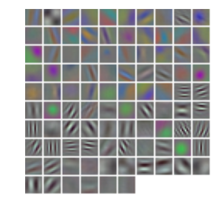

```python
# the parameters are a list of [weights, biases]
filters = net_bvlc.params['conv1'][0].data
vis_square(filters.transpose(0, 2, 3, 1))

# The parameters are fixed once training is finished
```

Activation of each filter in response to the input image. Brighter areas mean it responded strongly. In the first layer, we can still see large objects obviously. Going to deeper convolutions, more of the original image impacts each pixel in the activation. Therefore, it quickly becomes difficult or impossible to recognize parts of the original image in deeper convolutions.

ImageNet activation (Convolution 1) to the above image:

```
(560, 560)
```

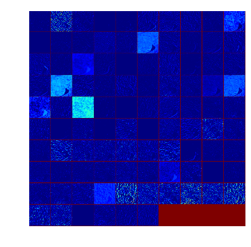

```python
# Using the BVLC-AlexNet
feat = net_bvlc.blobs['conv1'].data[0, :]
vis_square(feat)
```

Filters for ImageNet transferred weights, allowed to fine-tune on the M0 / M1 task:

```
(120, 120, 3)
```

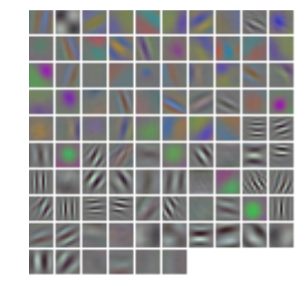

```python
# the parameters are a list of [weights, biases]
filters = net_transfer.params['conv1'][0].data
vis_square(filters.transpose(0, 2, 3, 1))

# The parameters are fixed once training is finished
```

And the first convolution activations:

```
(560, 560)
```

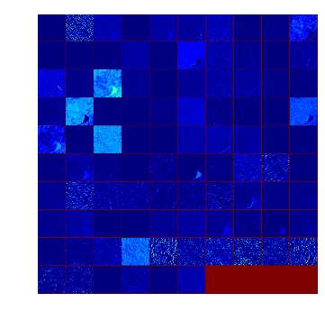

```python
# Using the Transferred / Fine tuned model
feat = net_transfer.blobs['conv1'].data[0, :]
vis_square(feat)
```

Filters learned end-to-end from random intialization on the M0 / M1 task:

```
(120, 120, 3)
```

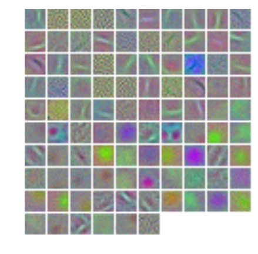

```python
# the parameters are a list of [weights, biases]
filters = net_end2end.params['conv1'][0].data
vis_square(filters.transpose(0, 2, 3, 1))

# The parameters are fixed once training is finished
```

And the corresponding activations:

```
(560, 560)
```

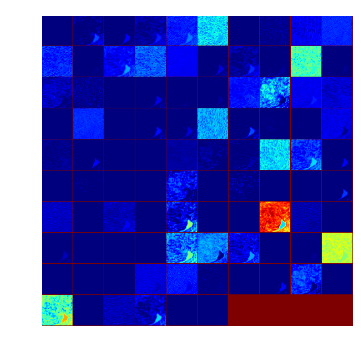

```python
# Using end-to-end trained model
feat = net_end2end.blobs['conv1'].data[0, :]
vis_square(feat)
```

GoogLeNet filters (Convolution 1 7x7 kernel stride 2) learned end-to-end on a non-multiplied dataset , for the M0 / M1 task:

```
(64, 64, 3)
```

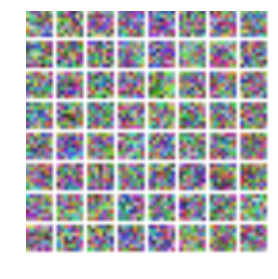

```python
# the parameters are a list of [weights, biases]
filters = net_google.params['conv1/7x7_s2'][0].data
vis_square(filters.transpose(0, 2, 3, 1))

# The parameters are fixed once training is finished
```

And the activations:

```
(904, 904)
```

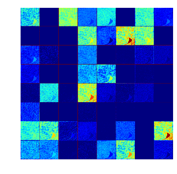

```python
# Using GoogLeNet model
feat = net_google.blobs['conv1/7x7_s2'].data[0, :]
vis_square(feat)
```

This part I don't understand fully. `fc7` is one of the `fully connected` layers. It is essentially a 4096 - element long feature vector. This is the input to the softmax classifier at the end.

The histogram on bottom summarizes the frequency of activations in `fc7`.

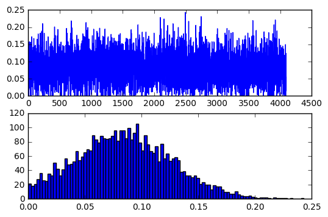

```python
feat = net_end2end.blobs['fc7'].data[0]
plt.subplot(2, 1, 1)
plt.plot(feat.flat)
plt.subplot(2, 1, 2)
_ = plt.hist(feat.flat[feat.flat > 0], bins=100)
```